# Model specification and diagnostics

Statistics and Data Science II · Week 3

Jesper Lindmarker

## Last week

- **Multiple regression:** a second predictor, and a coefficient that moved
- **Confounding:** a common cause. Leaving it out is **omitted variable bias**
- **Time:** a confounder comes before the predictor
- **Ceteris paribus:** each coefficient is read with the others held constant
- **R-squared:** how much of the variation the model accounts for
- **Uncertainty:** the standard error, the 95% confidence interval and the p-value

## Spurious correlations

https://tylervigen.com/

- Real data series that move together, with no reason to think one affects the other.
- Pick one. Is it something else causing both, chance, or something else?

Many of them both rise or fall over the same years. Time can be a common cause too.

## Today

**In the lecture**

1. Where the exam data come from
2. **Categorical predictors**
3. Adding the confounders
4. The reviewer’s variables: **adjusted R-squared**, **collinearity**, **mediators**, **common effects**
5. Without the true effect
6. **Diagnostics**, **size and units**

**In the lab**

1. What each variable is
2. Six models in one table
3. Answering the reviewer
4. Size, and the discussion
5. Finishing Report 2

## Today’s question

You send Model 2 to a journal. A reviewer writes back:

> “Accounting for controls and holding them constant takes us closer to the true causal effect. You should control for everything in your dataset.”
- Which variables should go in a model? Deciding this is called **model specification**.

## My drawing

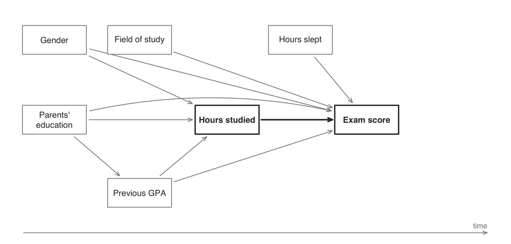

This drawing is not an assumption, as yours are: it is how the data were simulated by me.

## Today, three more variables

# Categorical predictors

## Types of variables

A recap from SDS I.

| Type | What the values are | In the exam data |
| --- | --- | --- |
| **Numerical**, continuous | Any value in a range | Hours studied, exam score |
| **Numerical**, discrete | Whole numbers, often counts | Parents’ education, in years |
| **Categorical**, nominal | Groups with no order | Field of study, gender |
| **Categorical**, ordinal | Groups in an order | None here. Level of education, for example |

Numerical variables are also called quantitative, and categorical ones qualitative.

## Types in R

```r
glimpse(ex)
```

```
Rows: 500
Columns: 7
$ exam_score        <int> 116, 106, 123, 123, 117, 116, 112, 124, 112, 123, 12…
$ hours_studied     <dbl> 26.2, 33.0, 51.5, 42.6, 35.4, 53.8, 62.9, 57.7, 62.2…
$ previous_gpa      <int> 84, 60, NA, 93, 89, 72, 90, 77, 60, 52, 96, 86, 63, …
$ hours_slept       <dbl> 7.2, 9.3, 7.7, 5.2, 10.8, 10.0, 10.7, 9.5, 5.3, 7.9,…
$ gender            <int> 0, 1, 1, 0, 0, 1, 1, 1, 1, 0, 0, 1, 1, 0, 0, 1, 0, 1…
$ parents_edu_years <int> 13, 9, 13, 12, 15, 16, 20, 16, 11, 12, 20, 8, 13, 11…
$ field             <chr> "natural_sci", "humanities", "natural_sci", "natural…
```

- `<dbl>` and `<int>` are numbers. `<chr>` is text, and `lm()` reads it as groups.
- `gender` is stored as a number, 0 and 1, but it stands for two groups.
- `factor()` makes a categorical variable with its groups in a set order. You did this for abuse in the lab today.

## Variables that are not numbers

So far our predictors have been numbers. Sometimes we want a **categorical** predictor:

- Field of study: humanities, natural science, social science
- Region or country
- Woman or man

## Two groups makes a dummy variable

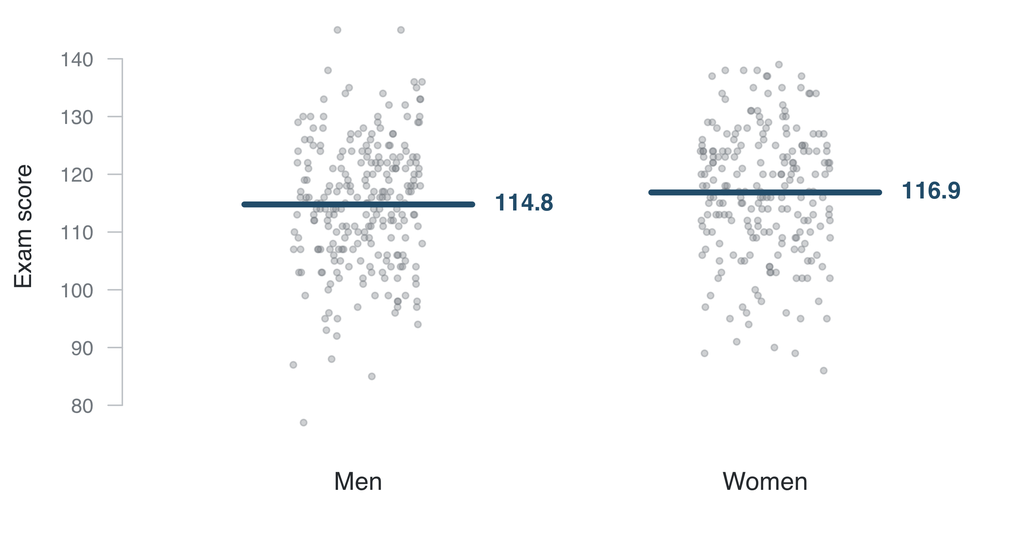

A variable coded 0 and 1 is called a **dummy variable**. Women (coded 1) scored 2.08 points higher than men on average.

## A dummy variable in R

```
Coefficients:
            Estimate Std. Error t value Pr(>|t|)
(Intercept) 114.7792     0.7119 161.237   <2e-16 ***
woman         2.0773     1.0343   2.008   0.0452 *
---
Signif. codes:  0 '***' 0.001 '**' 0.01 '*' 0.05 '.' 0.1 ' ' 1

Residual standard error: 11.03 on 454 degrees of freedom
Multiple R-squared:  0.008806,  Adjusted R-squared:  0.006623
```

- A man, woman = 0: **114.78**, the mean for men.
- A woman, woman = 1: 114.78 + 2.08 = **116.86**, the mean for women.

## Reading a dummy variable

- The **intercept** is the mean of the group coded 0. This group is the **reference category**.
- The **coefficient** is the difference between the two groups.

**Write it like this**

On average, women score **2.08 points** higher than men.

There is no “one-unit increase” in being a woman, so the sentence has no units of the predictor.

## Three groups

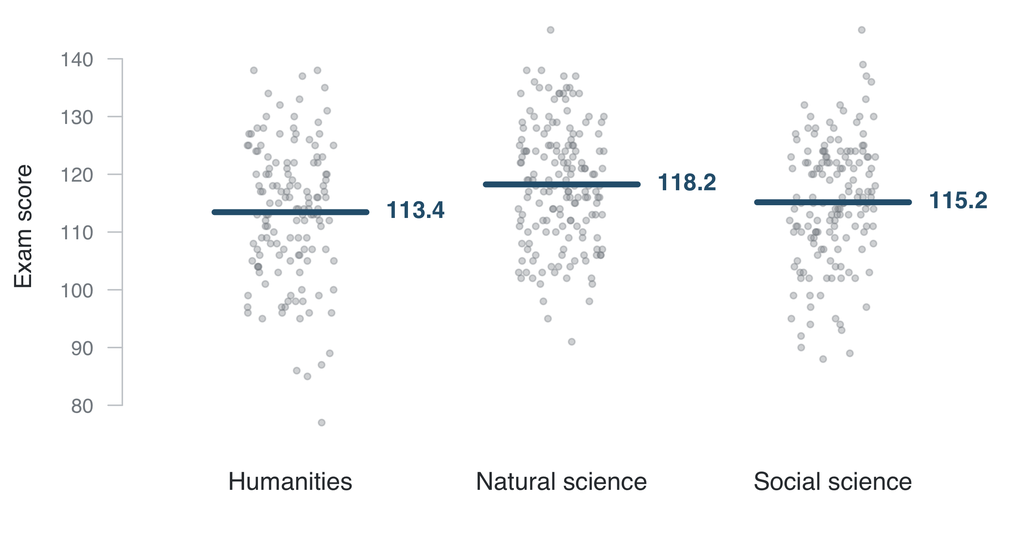

Field of study

## Three groups in R

```
Coefficients:
                 Estimate Std. Error t value Pr(>|t|)
(Intercept)      113.4420     0.9284 122.190  < 2e-16 ***
fieldnatural_sci   4.8050     1.2564   3.824 0.000149 ***
fieldsocial_sci    1.7159     1.2824   1.338 0.181555
---
Signif. codes:  0 '***' 0.001 '**' 0.01 '*' 0.05 '.' 0.1 ' ' 1

Residual standard error: 10.91 on 453 degrees of freedom
Multiple R-squared:  0.03273,   Adjusted R-squared:  0.02846
```

Three groups, and only two coefficients. Where did humanities go?

## The reference category

- Humanities is the **intercept**: 113.44, the mean for humanities.
- The other two are **differences from humanities**:
  - Natural science: 113.44 + 4.80 = 118.25
  - Social science: 113.44 + 1.72 = 115.16
- *(R has made a dummy variable for each group except one. A student who is in neither of the two is in humanities.)*

With k groups there are k − 1 coefficients. The reference category is also called the baseline or the omitted category.

## Changing the reference

R picks the first group in the alphabet. We can change it:

```r
exam <- exam |> mutate(field = relevel(factor(field), ref = "social_sci"))
```

```
Coefficients:
                 Estimate Std. Error t value Pr(>|t|)
(Intercept)      115.1579     0.8846 130.178   <2e-16 ***
fieldhumanities   -1.7159     1.2824  -1.338    0.182
fieldnatural_sci   3.0891     1.2244   2.523    0.012 *
---
Signif. codes:  0 '***' 0.001 '**' 0.01 '*' 0.05 '.' 0.1 ' ' 1

Residual standard error: 10.91 on 453 degrees of freedom
Multiple R-squared:  0.03273,   Adjusted R-squared:  0.02846
```

Now social science is the intercept: 115.16. The coefficients change. The group means, the predictions and R-squared do not.

## With other predictors

```
Call:
lm(formula = exam_score ~ hours_studied + previous_gpa + woman +
    field, data = exam)

Residuals:
    Min      1Q  Median      3Q     Max
-26.144  -5.480   0.047   5.252  22.319

Coefficients:
                 Estimate Std. Error t value Pr(>|t|)
(Intercept)      72.60108    2.13105  34.068  < 2e-16 ***
hours_studied     0.21279    0.03175   6.702 6.18e-11 ***
previous_gpa      0.41277    0.02451  16.843  < 2e-16 ***
woman             2.13859    0.75145   2.846  0.00463 **
fieldnatural_sci  5.25929    0.90992   5.780 1.40e-08 ***
fieldsocial_sci   1.96315    0.92695   2.118  0.03473 *
---
Signif. codes:  0 '***' 0.001 '**' 0.01 '*' 0.05 '.' 0.1 ' ' 1

Residual standard error: 7.883 on 450 degrees of freedom
Multiple R-squared:  0.4981,    Adjusted R-squared:  0.4925
F-statistic: 89.31 on 5 and 450 DF,  p-value: < 2.2e-16
```

**Write it like this**

**Holding hours, GPA and gender constant**, those from natural science score **5.26 points** higher than those from humanities on average.

# Adding the confounders

## The common causes

Which variables affect both hours studied and the exam score?

## Five models, each with one more confounder

|  | Model 1 | Model 2 | Model 3 | Model 4 | Model 5 |
| --- | --- | --- | --- | --- | --- |
| Hours studied | 0.34 | 0.22 | 0.20 | 0.21 | 0.20 |
|  | (0.04) | (0.03) | (0.03) | (0.03) | (0.03) |
| Previous GPA |  | 0.41 | 0.41 | 0.41 | 0.41 |
|  |  | (0.03) | (0.03) | (0.02) | (0.03) |
| Woman |  |  | 2.33 | 2.14 | 2.14 |
|  |  |  | (0.78) | (0.75) | (0.75) |
| Natural science |  |  |  | 5.26 | 5.18 |
|  |  |  |  | (0.91) | (0.92) |
| Social science |  |  |  | 1.96 | 1.89 |
|  |  |  |  | (0.93) | (0.93) |
| Parents' education |  |  |  |  | 0.09 |
|  |  |  |  |  | (0.11) |
| Intercept | 100.65 | 76.53 | 75.52 | 72.60 | 72.25 |
|  | (1.82) | (2.11) | (2.11) | (2.13) | (2.17) |
| Num.Obs. | 456 | 456 | 456 | 456 | 456 |
| R2 | 0.140 | 0.449 | 0.459 | 0.498 | 0.499 |

Standard errors in brackets.

## What moved, and what did not

- **Model 3, gender:** a confounder. Hours moved from 0.22 to 0.20.
- **Model 4, field:** affects only the score. R-squared rose from 0.46 to 0.50. Hours moved back to 0.21: chance in our sample, not bias.
- **Model 5, parents’ education:** a confounder. Hours moved to 0.20.
- All in all, hours moved only a little. GPA, last week, did most of the work.
- Model 5 has every confounder in the drawing.

# Adding other variables

## The other variables

## Which variables belong?

For each variable, we can add it to Model 5 and ask:

1. What happens to the coefficient we care about?
2. What happens to its standard error?
3. What happens to R-squared?
4. Does the variable belong in the model?

# An unrelated variable

## Seat row is unrelated

## Model 5

Before we add anything, Model 5 as R prints it.

```
Coefficients:
                  Estimate Std. Error t value Pr(>|t|)
(Intercept)       72.25066    2.17235  33.259  < 2e-16 ***
hours_studied      0.20470    0.03320   6.167 1.56e-09 ***
previous_gpa       0.40740    0.02534  16.079  < 2e-16 ***
woman              2.13616    0.75170   2.842  0.00469 **
fieldnatural_sci   5.17876    0.91528   5.658 2.73e-08 ***
fieldsocial_sci    1.88515    0.93191   2.023  0.04368 *
parents_edu_years  0.08884    0.10597   0.838  0.40228
---
Signif. codes:  0 '***' 0.001 '**' 0.01 '*' 0.05 '.' 0.1 ' ' 1

Residual standard error: 7.885 on 449 degrees of freedom
Multiple R-squared:  0.4989,    Adjusted R-squared:  0.4922
```

R-squared is 0.4989. Next to it is a number we have not used yet: adjusted R-squared.

## Seat row

`seat_row`: the row each student sat in at the exam. Which was random.

```
Coefficients:
                  Estimate Std. Error t value Pr(>|t|)
(Intercept)       72.90971    2.29249  31.804  < 2e-16 ***
hours_studied      0.20423    0.03321   6.150 1.71e-09 ***
previous_gpa       0.40692    0.02535  16.053  < 2e-16 ***
woman              2.10907    0.75246   2.803  0.00528 **
fieldnatural_sci   5.19703    0.91570   5.675 2.49e-08 ***
fieldsocial_sci    1.94621    0.93456   2.082  0.03787 *
parents_edu_years  0.09099    0.10602   0.858  0.39119
seat_row          -0.05880    0.06522  -0.902  0.36780
---
Signif. codes:  0 '***' 0.001 '**' 0.01 '*' 0.05 '.' 0.1 ' ' 1

Residual standard error: 7.887 on 448 degrees of freedom
Multiple R-squared:  0.4998,    Adjusted R-squared:  0.4919
```

R-squared rose from 0.4989 to 0.4998. **R-squared never falls** when a predictor is added, even a random one.

## Adjusted R-squared

- R-squared never falls when we add a predictor, even one that is noise.
- **Adjusted R-squared** is R-squared with a **penalty for each predictor**.
- A new predictor raises it only if it explains more than a random one would.
- So we use it to **compare models with different numbers of predictors**.

## The calculation

$$\text{Adjusted } R^2 = 1 - (1 - R^2) \times \frac{n - 1}{n - k - 1}$$

- n is the number of observations, and k the number of predictors.
- 1 − R² is the share of the variation the model leaves unexplained.
- The fraction is a little above 1, and grows with every predictor. That is the charge.

## Reading adjusted R-squared

- It is **not** a share of the variation. “The model explains 50% of the variation” is said about R-squared.
- It is always a little below R-squared. With many observations and few predictors, the two are close.
- It says how well a model **predicts**, not whether a coefficient is biased.

## When to use it

- Show both R-squared and adjusted R-squared in your regression tables.
- Use adjusted R-squared when you **compare models with different numbers of predictors**.
- Do **not** use it to decide which variables belong. The drawing and the question do that.

**Write it like this**

Adding seat row lowered adjusted R-squared from 0.4922 to 0.4919, so it does not improve the model’s predictions.

# Collinearity

## When two variables explain the same thing

## Hours logged

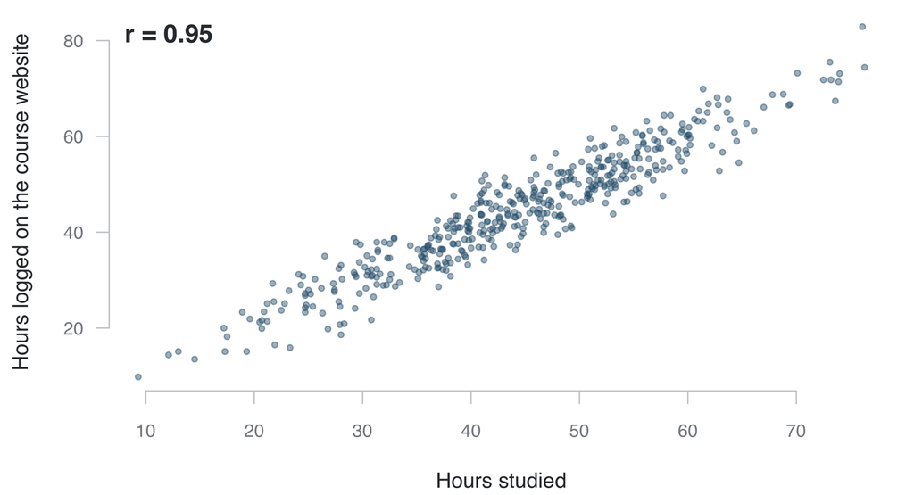

The hours each student was logged in to the course website. It follows hours studied closely.

## The correlation matrix

|  | Exam score | Hours studied | Hours logged |
| --- | --- | --- | --- |
| Hours studied | .37 |  |  |
| Hours logged | .36 | **.95** |  |
| Previous GPA | .63 | .24 | .24 |

A high correlation **between two predictors** can cause collinearity in the model.

## Adding hours logged

|  | Model 5 | Model 5 + hours logged |
| --- | --- | --- |
| Hours studied | 0.20 | 0.21 |
|  | (0.03) | (0.10) |
| Previous GPA | 0.41 | 0.41 |
|  | (0.03) | (0.03) |
| Woman | 2.14 | 2.14 |
|  | (0.75) | (0.75) |
| Natural science | 5.18 | 5.18 |
|  | (0.92) | (0.92) |
| Social science | 1.89 | 1.88 |
|  | (0.93) | (0.93) |
| Parents' education | 0.09 | 0.09 |
|  | (0.11) | (0.11) |
| Hours logged |  | -0.00 |
|  |  | (0.09) |
| Num.Obs. | 456 | 456 |
| R2 | 0.499 | 0.499 |

Standard errors in brackets.

## What hours logged did

- Hours’ coefficient barely moved: 0.20 to 0.21.
- The standard error of hours is **3 times** as large.
- Hours logged gets almost nothing. Was that luck?

## Collinearity

**Collinearity**

Two or more predictors are so closely related that the model cannot tell their parts apart. Also called multicollinearity.

- The standard errors of those predictors **grow**, and their coefficients become unreliable.
- It does **not** bias them.
- The model as a whole **predicts just as well**.

## What to do about collinearity

- Ask whether the two variables measure the **same thing**. If so, use one of them, chosen in advance.
- If both matter for the question, keep both, accept the wide intervals and say why.
- Do **not** keep whichever has the smaller p-value.

# Mediators

## Confounder and mediator

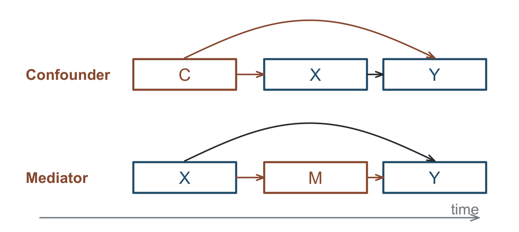

The same three boxes. A confounder comes before X and causes it. A mediator comes after X and is caused by it. X is the predictor, Y the outcome.

## Mediator

**Mediator**

A variable that the predictor works **through**, between the predictor and the outcome. It is on the causal **path** between the predictor and the outcome.

## Another question

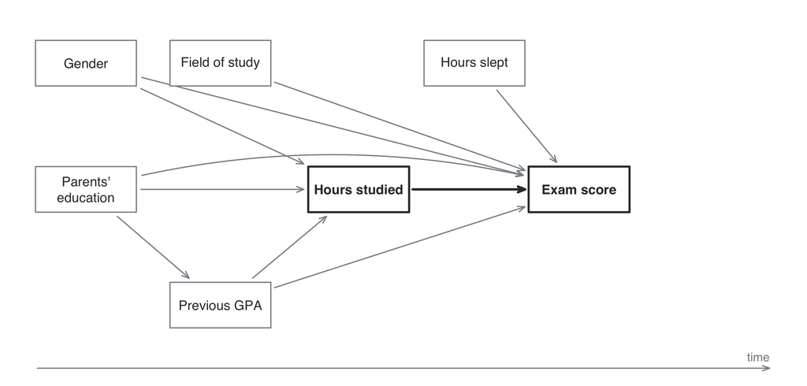

Do children of more educated parents score higher? Now parents’ education is the predictor. Where are hours studied and previous GPA?

## Adding the mediators

|  | Model 1 | Model 2: + hours | Model 3: + hours, GPA |
| --- | --- | --- | --- |
| Parents' education | 0.86 | 0.56 | 0.15 |
|  | (0.13) | (0.13) | (0.11) |
| Hours studied |  | 0.28 | 0.20 |
|  |  | (0.04) | (0.03) |
| Previous GPA |  |  | 0.40 |
|  |  |  | (0.03) |
| Num.Obs. | 456 | 456 | 456 |
| R2 | 0.091 | 0.174 | 0.451 |

Children of more educated parents study more (1.1 hours per year) and have higher GPAs (1.3 points). Did parents’ education stop mattering?

## Which model?

- “Do children of more educated parents score higher?” Without the mediators: **0.86**, the **total** association.
- “Do they score higher **beyond** studying more and having better grades?” With the mediators: **0.15**, the **direct** part.

Parents’ education did not stop mattering. The third model answers a narrower question.

## One variable, two roles

| Question | Previous GPA is | Should it go in? |
| --- | --- | --- |
| Does studying raise the score? | A confounder | Yes |
| Do children of more educated parents score higher? | A mediator | No |

- In both cases, a coefficient **moved** when GPA was added.
- Mediators in models are tricky business. But if you are looking for the causal effect of a predictor, you “generally” do not include mediators.

# Common effects and sample selection

## Teaching assistants

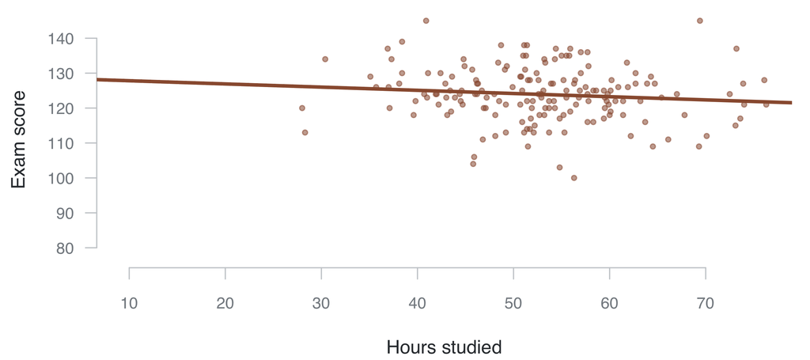

Next year’s 171 teaching assistants, picked for **high scores** or for **working hard**. Among them, more hours goes with a **lower** score.

## Everyone

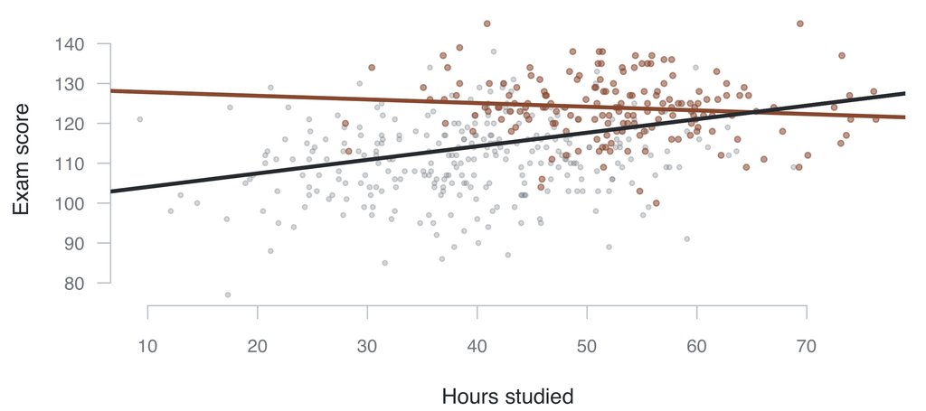

Among all students, more hours goes with a higher score. A TA with few hours was probably picked for a high score, and one with a low score for many hours.

## A common effect

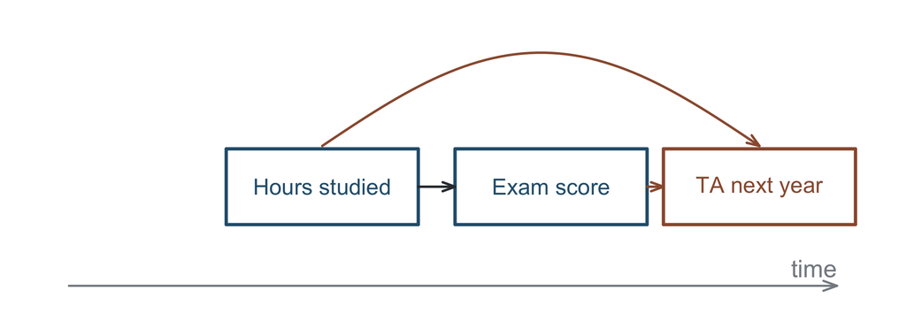

Being picked as a TA is a **common effect** of hours and the score. It comes after both.

## Adding TA next year

|  | Model 5 | Model 5 + TA next year |
| --- | --- | --- |
| Hours studied | 0.20 | 0.05 |
|  | (0.03) | (0.03) |
| Previous GPA | 0.41 | 0.36 |
|  | (0.03) | (0.02) |
| Woman | 2.14 | 2.00 |
|  | (0.75) | (0.69) |
| Natural science | 5.18 | 4.27 |
|  | (0.92) | (0.85) |
| Social science | 1.89 | 1.63 |
|  | (0.93) | (0.86) |
| Parents' education | 0.09 | 0.03 |
|  | (0.11) | (0.10) |
| TA next year |  | 7.89 |
|  |  | (0.88) |
| Num.Obs. | 456 | 456 |
| R2 | 0.499 | 0.576 |

Standard errors in brackets.

## Within each group

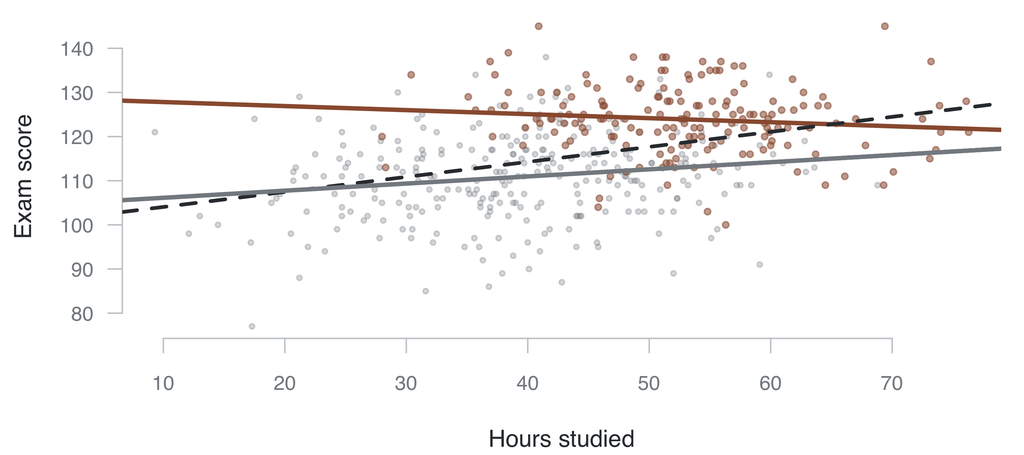

TAs in brown, everyone else in grey, each with its own line. Both lines are flatter than the line for all students (dashed).

## What happened to hours?

- Adding TA next year means comparing students **with the same TA status**: TAs with TAs, the rest with the rest.
- Among TAs, those with few hours were picked for a high score. Among the rest, those with many hours were not picked, so their scores were lower.
- Within each group, the link between hours and the score is weaker than it really is, and among TAs even negative. Hours moves from 0.20 to 0.05.
- This is a **spurious association**: it comes from how TAs were picked, not from studying.

## And TA itself?

- TA next year gets 7.89 points, and R-squared rises from 0.50 to 0.58.
- But students are picked **after** the exam. Being a TA next year cannot affect this year’s score. The score affects being picked.
- We cannot explain an outcome with something that happened after it.
- A model can fit better and still be wrong.

## A selected sample

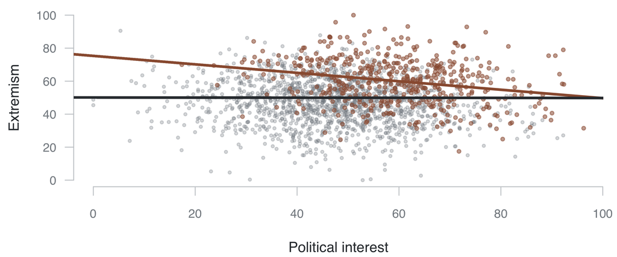

Made-up data. Among Twitter users (brown), more interest goes with **less extremism**. Among everyone, there is no link.

## Three places on the time line

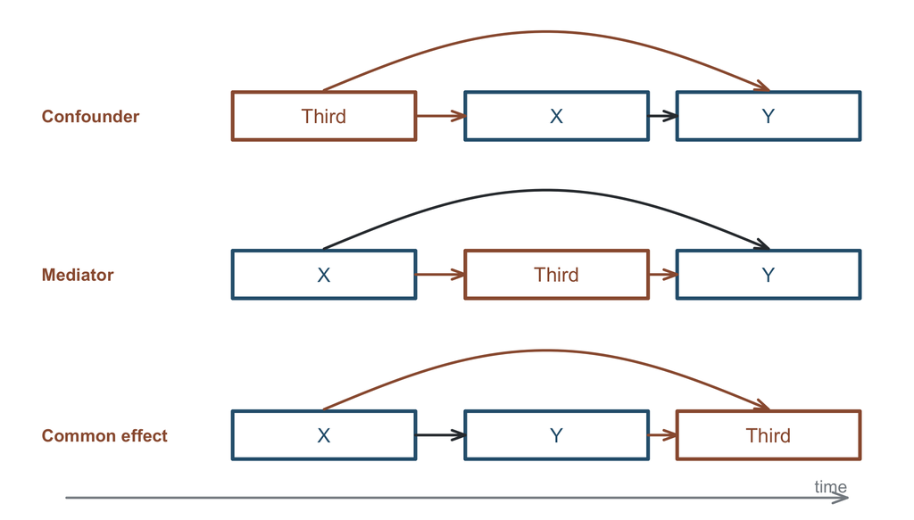

The same three boxes, with the third variable in a different place. X is the predictor, Y the outcome.

## Should it go in?

|  | Where it comes | Should it go in? |
| --- | --- | --- |
| **Confounder** | Before the predictor, and affects both | Yes |
| **Mediator** | Between the predictor and the outcome | It depends on the question |
| **Common effect** | After the outcome | No |

The time line limits what a variable can be. The arrows in your drawing say which one you assume it is. Something that affects only one of the two is none of these.

# The reviewer’s model

## Comparing the two models

|  | Model 5 | Reviewer |
| --- | --- | --- |
| Hours studied | 0.20 (0.03) | 0.01 (0.09) |
| Previous GPA | 0.41 (0.03) | 0.35 (0.02) |
| Woman | 2.14 (0.75) | 2.05 (0.69) |
| Natural science | 5.18 (0.92) | 4.25 (0.84) |
| Social science | 1.89 (0.93) | 1.58 (0.86) |
| Parents' education | 0.09 (0.11) | 0.05 (0.10) |
| Hours slept |  | 0.68 (0.23) |
| Seat row |  | -0.04 (0.06) |
| Hours logged |  | 0.05 (0.09) |
| TA next year |  | 7.73 (0.87) |
| Num.Obs. | 456 | 456 |
| R2 | 0.499 | 0.585 |
| R2 Adj. | 0.492 | 0.576 |

Standard errors in brackets.

## Where every model’s estimate for hours lands

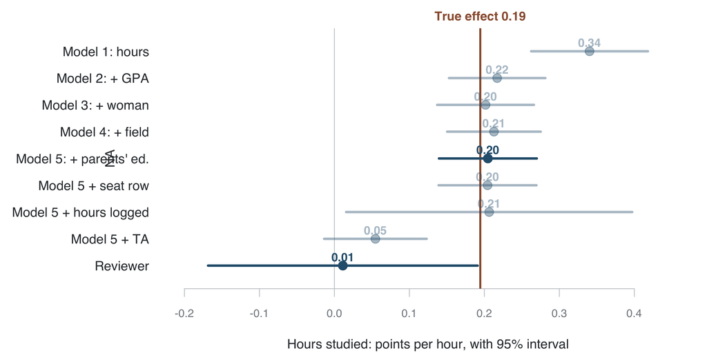

## A better fit, a worse answer

|  | Model 5 | Reviewer |
| --- | --- | --- |
| R-squared | 0.499 | **0.585** |
| Adjusted R-squared | 0.492 | **0.576** |
| Hours studied | **0.20** (95% CI 0.14 to 0.27) | 0.01 (95% CI -0.17 to 0.19) |

- The reviewer’s model **predicts better**, and its estimate is **further from the truth**.

## Back to the reviewer

> “You should control for everything in your dataset.”
- No. We control for what our causal assumptions inform us to control for.
- That is model specification.

# Diagnostics

## Diagnostics

- Linear regression rests on assumptions, often called the **OLS assumptions**. For example: that a straight line is the right shape.
- Checks on a model are called **diagnostics**.
- We will not go through every assumption in this course. We use two diagnostics:
  - Checking for **collinearity**.
  - The distribution of **residuals** over fitted values.

For the full list, see ROS chapter 11, “Assumptions, diagnostics, and model evaluation”.

## The residuals, as in Week 1

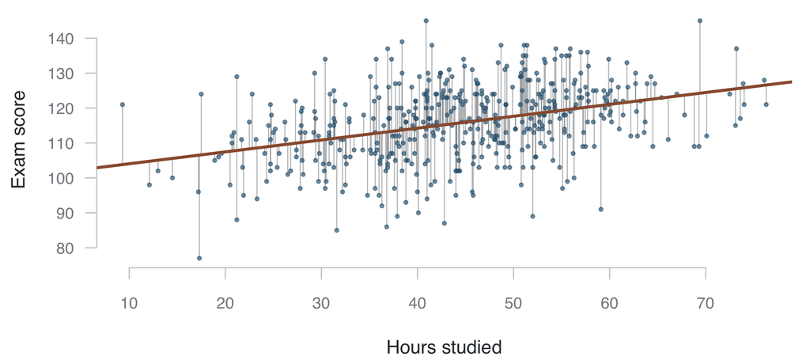

Model 1. Each grey segment is a residual. If a straight line is the right shape, students are spread evenly above and below it, all along the line.

## Laying the line flat

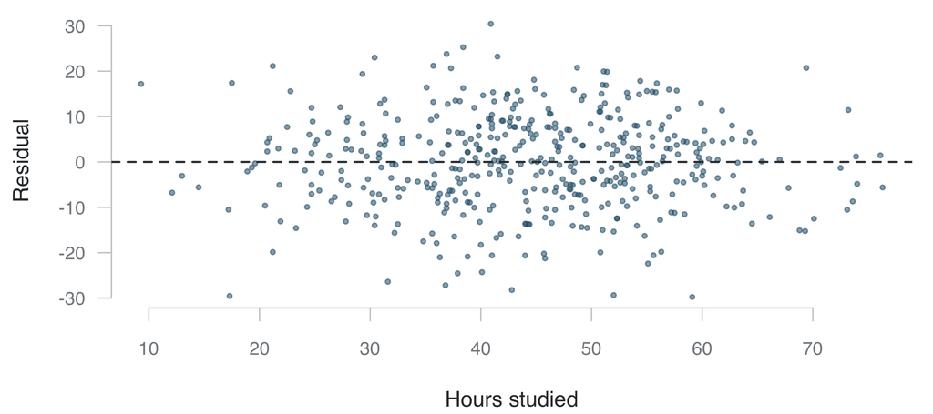

The same residuals, against hours. The line is now the dashed zero. At every number of hours, about as many students are above it as below. No pattern.

## If hours had a curved effect

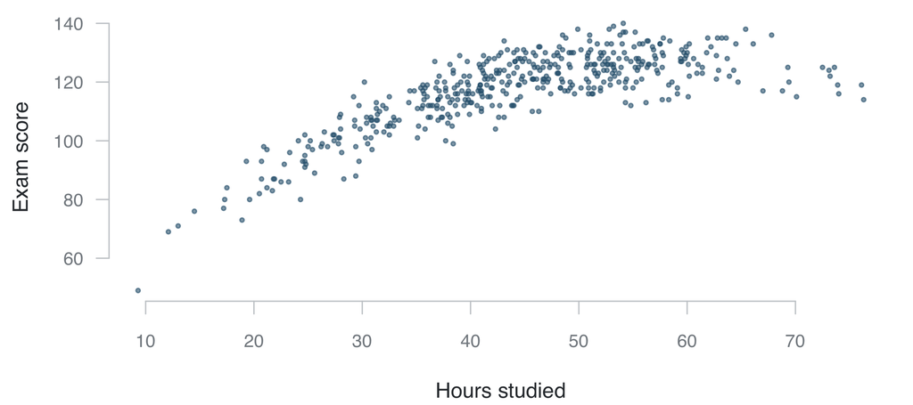

Made-up scores, in which each extra hour adds less than the one before.

## If hours had a curved effect

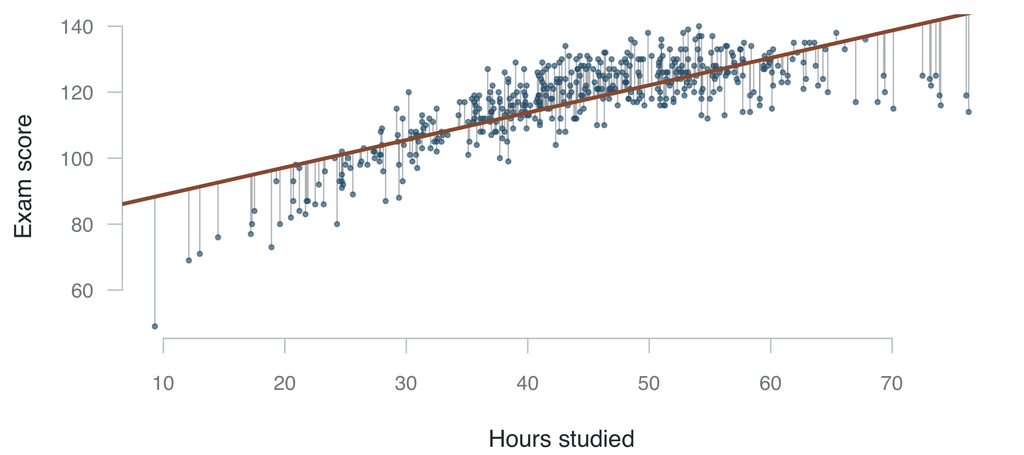

With a straight line and its residuals. The line is too high at both ends and too low in the middle.

## Laying that line flat

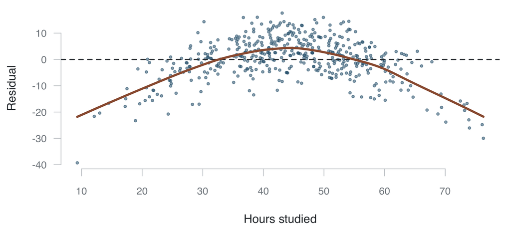

The residuals form an arch: below zero at both ends, above it in the middle. The brown line follows the average residual. A straight line is the **wrong shape**.

## With several predictors

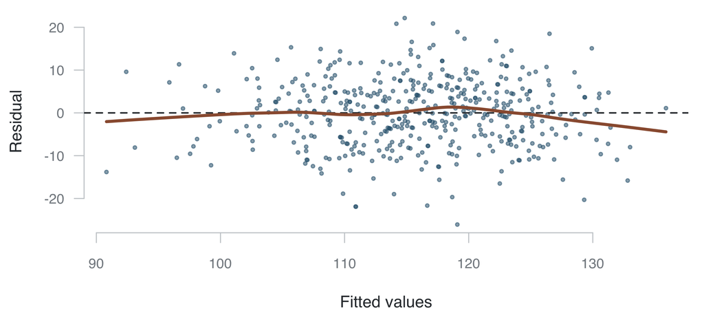

Model 5 has five predictors, so there is no single x. We plot the residuals against the **fitted values** instead. No arch: the brown line stays near zero.

## Residuals in R

```r
plot(m5, which = 1)
```

- This draws the residuals against the fitted values, with a red line through the average residual.
- Look for a **pattern**: an arch, a U, or a spread that widens. No pattern is what we want.
- Fitted values are the same as predicted values.

# Size and units

## Two kinds of significance

- **Statistical significance:** the coefficient can be told apart from zero.
- **Substantive significance:** it is large enough to matter. Also called practical significance.
- Hours’ coefficient in Model 5 has p < 0.001. It is 0.20 points per hour. Is that large?
- To answer, we have to look at the **units**.

## The units of a predictor

Model 5, with hours studied measured in hours.

```
Coefficients:
                  Estimate Std. Error t value Pr(>|t|)
(Intercept)       72.25066    2.17235  33.259  < 2e-16 ***
hours_studied      0.20470    0.03320   6.167 1.56e-09 ***
previous_gpa       0.40740    0.02534  16.079  < 2e-16 ***
woman              2.13616    0.75170   2.842  0.00469 **
fieldnatural_sci   5.17876    0.91528   5.658 2.73e-08 ***
fieldsocial_sci    1.88515    0.93191   2.023  0.04368 *
parents_edu_years  0.08884    0.10597   0.838  0.40228
---
Signif. codes:  0 '***' 0.001 '**' 0.01 '*' 0.05 '.' 0.1 ' ' 1

Residual standard error: 7.885 on 449 degrees of freedom
Multiple R-squared:  0.4989,    Adjusted R-squared:  0.4922
```

## In tens of hours

```r
exam <- exam |> mutate(hours10 = hours_studied / 10)
```

- A student who studied 40 hours now has 4.
- We fit Model 5 again with `hours10` instead of `hours_studied`. What happens to the coefficient, its standard error, the t value and R-squared?

## In tens of hours

```r
exam <- exam |> mutate(hours10 = hours_studied / 10)
```

```
Coefficients:
                  Estimate Std. Error t value Pr(>|t|)
(Intercept)       72.25066    2.17235  33.259  < 2e-16 ***
hours10            2.04699    0.33195   6.167 1.56e-09 ***
previous_gpa       0.40740    0.02534  16.079  < 2e-16 ***
woman              2.13616    0.75170   2.842  0.00469 **
fieldnatural_sci   5.17876    0.91528   5.658 2.73e-08 ***
fieldsocial_sci    1.88515    0.93191   2.023  0.04368 *
parents_edu_years  0.08884    0.10597   0.838  0.40228
---
Signif. codes:  0 '***' 0.001 '**' 0.01 '*' 0.05 '.' 0.1 ' ' 1

Residual standard error: 7.885 on 449 degrees of freedom
Multiple R-squared:  0.4989,    Adjusted R-squared:  0.4922
```

## In twenties of hours

```r
exam <- exam |> mutate(hours20 = hours_studied / 20)
```

```
Coefficients:
                  Estimate Std. Error t value Pr(>|t|)
(Intercept)       72.25066    2.17235  33.259  < 2e-16 ***
hours20            4.09398    0.66390   6.167 1.56e-09 ***
previous_gpa       0.40740    0.02534  16.079  < 2e-16 ***
woman              2.13616    0.75170   2.842  0.00469 **
fieldnatural_sci   5.17876    0.91528   5.658 2.73e-08 ***
fieldsocial_sci    1.88515    0.93191   2.023  0.04368 *
parents_edu_years  0.08884    0.10597   0.838  0.40228
---
Signif. codes:  0 '***' 0.001 '**' 0.01 '*' 0.05 '.' 0.1 ' ' 1

Residual standard error: 7.885 on 449 degrees of freedom
Multiple R-squared:  0.4989,    Adjusted R-squared:  0.4922
```

## The same model

- The coefficient and its standard error change with the unit: 0.205, 2.047 and 4.094 points.
- The t value (6.17), the p-value and R-squared (0.499) do not.
- Choose the unit that makes the coefficient easy to read and talk about.

## Judging size

A coefficient is in **units of y per unit of x**, so a small number can be a large difference. To judge size:

- Choose a **realistic difference** in x, not always one unit.
- Express the result on a scale that means something: in the units of y, and next to the **standard deviation of y**.
- Then argue for a judgement. There is usually no single right answer.

## Hours studied, in exam points

- Ten more hours is close to one standard deviation of hours (12.2).
- In Model 5, ten more hours is associated with **2.0 points** (95% CI 1.4 to 2.7).
- The standard deviation of exam scores is 11.1, so that is about **a fifth of a standard deviation**.

Is ten hours of study worth 2 points?

## Comparing two predictors

Does GPA (0.407) matter about twice as much as hours (0.205)? The units differ, so we compare one standard deviation of each.

|  | Coefficient | One SD | Coefficient × SD |
| --- | --- | --- | --- |
| Hours studied | 0.205 | 12.2 hours | **2.5 points** |
| Previous GPA | 0.407 | 15.6 GPA points | **6.4 points** |

A coefficient rescaled this way is called a **standardised coefficient**.

## What to take to the exam

**Be able to say what these are**

- A dummy variable, a reference category
- Adjusted R-squared
- Substantive significance
- Collinearity, and what it does not do
- A confounder, a mediator, a common effect
- A spurious association

**Be able to do these**

- Read a categorical predictor
- Compare two non-reference groups
- Change the units of a coefficient
- Place a variable on the time line
- Read a residual plot
- **Interpret a coefficient: its size, its interval, and whether the size matters**

## Note on terminology

Different fields use different words for the same thing.

| We say | Also called |
| --- | --- |
| Outcome | Dependent variable, response, y |
| Predictor | Independent variable, explanatory variable, regressor, covariate, x |
| Coefficient | Slope, estimate, b, β (beta) |
| Dummy variable | Indicator, binary or 0/1 variable |
| Reference category | Baseline, omitted category |
| Controlling for | Adjusting for, holding constant, conditioning on, net of, ceteris paribus |
| Mediator | Mechanism, intervening variable |
| Causal diagram | DAG (directed acyclic graph) |

## Note on terminology

And some words mean different things in different places.

| Word | In a regression | Can also mean |
| --- | --- | --- |
| Significant | Told apart from zero | Important, large |
| Effect | Papers often say it for an association | A cause |
| Control | A variable in the model | A control group in an experiment |
| Multivariate | Several outcomes | Several predictors, which is multiple regression |
| Error | The part of the outcome we cannot see. The residual is what we can calculate | A mistake |